# Final Portfolio - Static

###### UCID : 12149052

###### Name : Regina Widjaya

##### First Chart: H1-B Petition Approval Breakdown

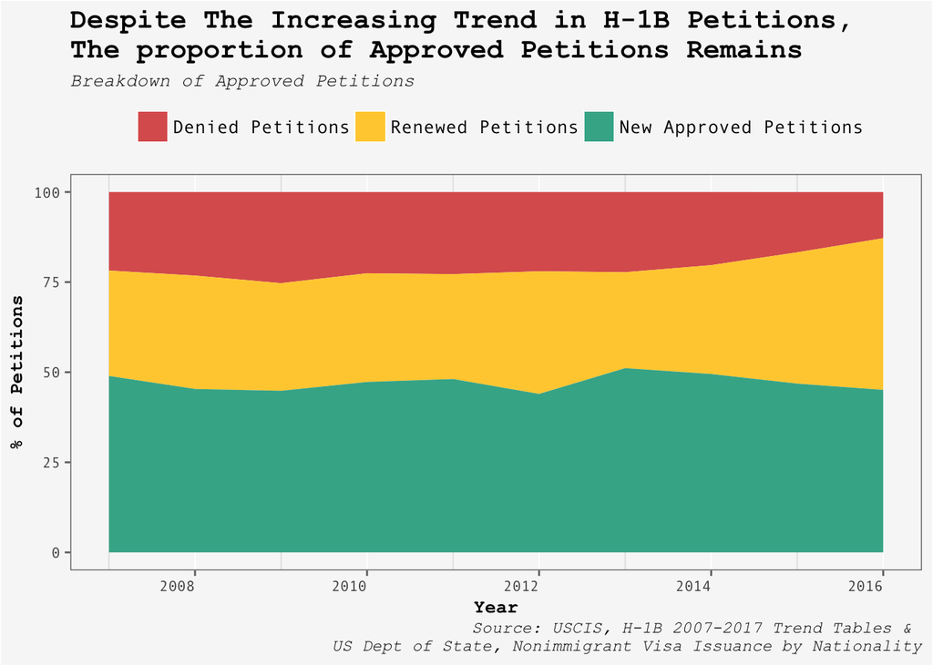

The graph is showing H1-B petition approval trends in the 10-year period from 2007 to 2016. ‘Denied’ signifies the proportion of petition request that were denied by the USCIS. The ‘Renewed Petitions’ area signify a portion of petitions that are approved for continuing workers with prior H1-B. As the name suggest, the ‘New Approved’ area signifies only the portion of the petitions that are approved for entirely new H1-B for new workers.

##### Second Chart: H1-B Petition Beneficiary’s Education Level

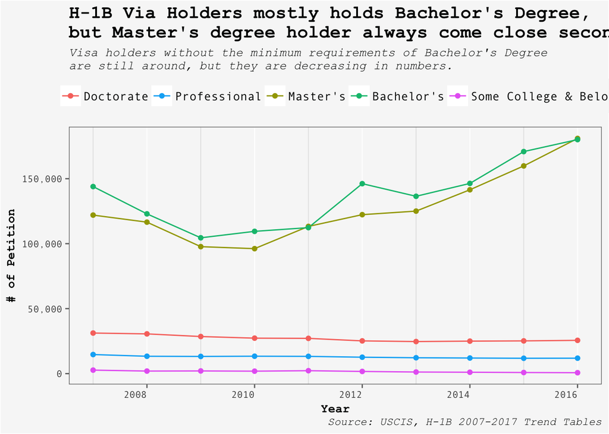

As the title suggests, this chart aims to display the academic make up of yearly H1-B petitioners. Since H1-B is a visa aimed for admitting highly-skilled individual, it is not surprising to see people who have ‘less than a bachelor degree’ would be less likely to apply. At the other end of the spectrum, Master’s Degree petitioners are slowly taking over their Bachelors Degree counterpart in terms of volume. This might mean that H1-B petitioners are gettting smarter, and the additional 20,000 master’s quota might be just as overcrowded as the regular visa cap.

##### Third Chart: H1-B Petition Income Make Up

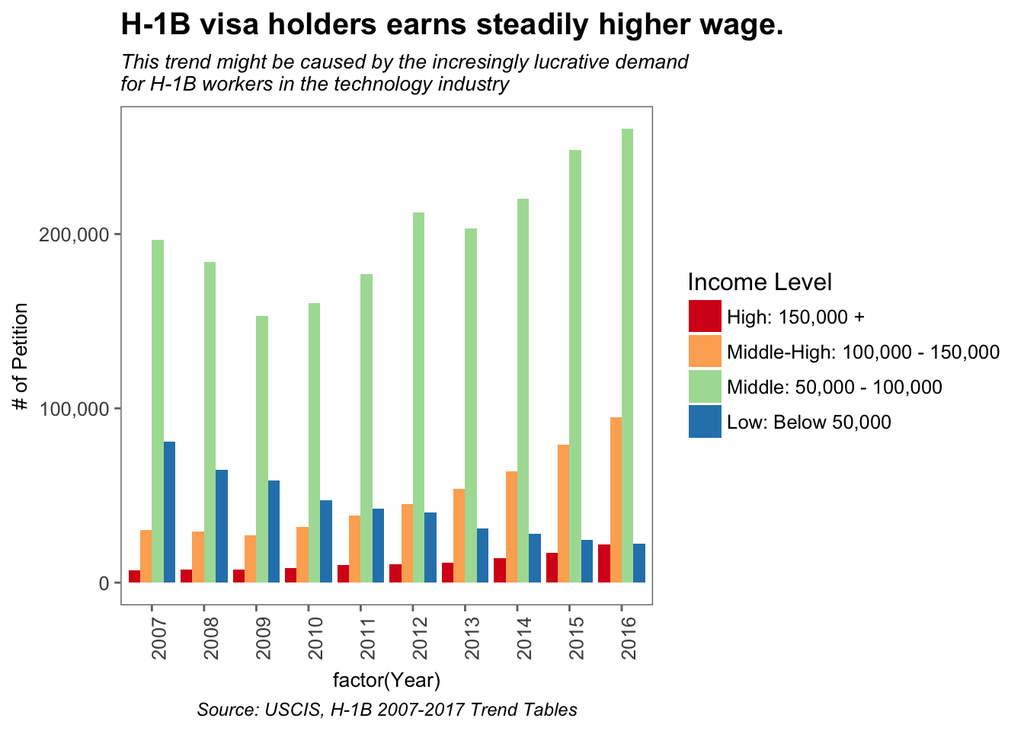

In this chart, we can explicitly see that H1-B petitioners over the years are getting paid higher than their predecessors. This trend might be caused by the prevalence of high-paying technology jobs that attracts top international talent and therefore requires H1-B certification. It might also be caused by the perpetually rising administration cost for h1-b visa that can be cost-prohibitive for interested applicants in lower income brackets. There are numerous claims by resercher that H1-B workers are generally paid less than their American counterpart. The project will try to dig deeper on that claim.

##### Fourth Chart: Top 20 H1-B Sponsors of Approved Petition Wage Comparison

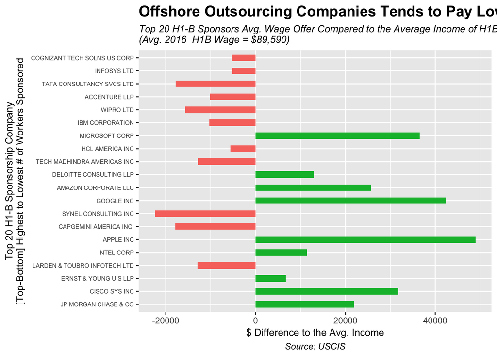

The top 5 h1-b sponsors are actually paying their workers less than the average wage of h1-b workers in 2016. This might be an interesting starting point in finding proof to the h1-b underpayment problem. Further in-depth investigation towards industry and job specific income standard are in order.

##### Fifth Chart: (SLOPE Chart) 5-Year Change in H1-B Approved Petition

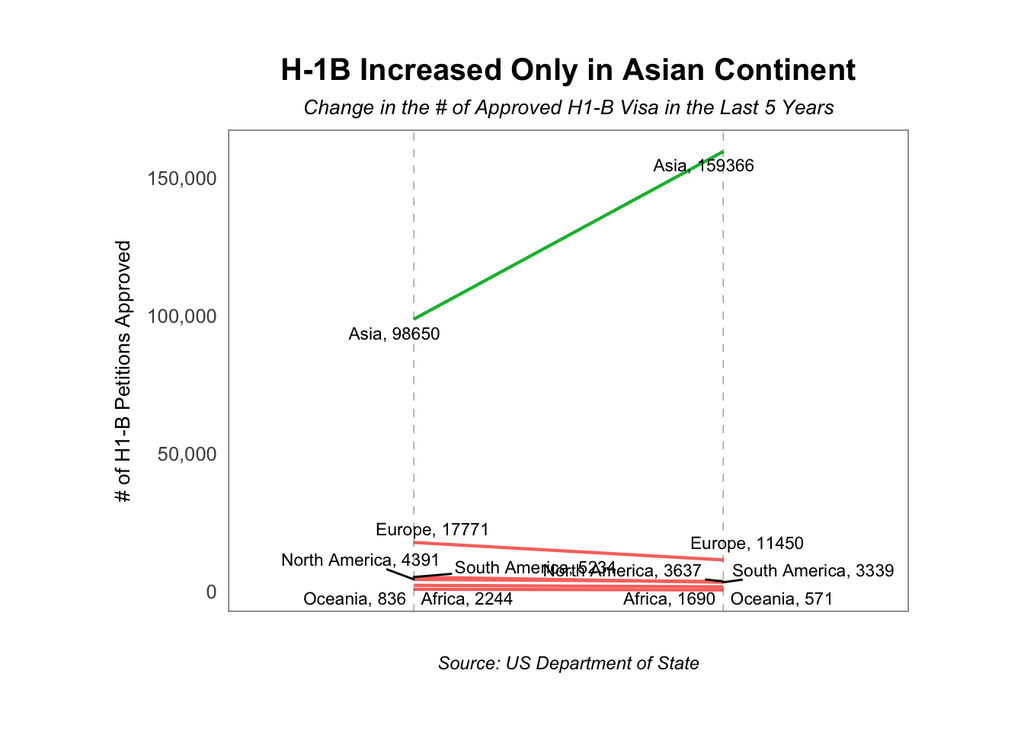

In this chart, international workers from Asia not only dominates the general make up of approved h1-b visa, but it also the only one that is showm to have an upward trend when it comes to the work visa application. This might have been cause by the historically high traffic of Indian worker in the h1-b system. Further investigation must be made in order to ensure fairness between applicants.

##### Sixth Chart: Barbell Chart

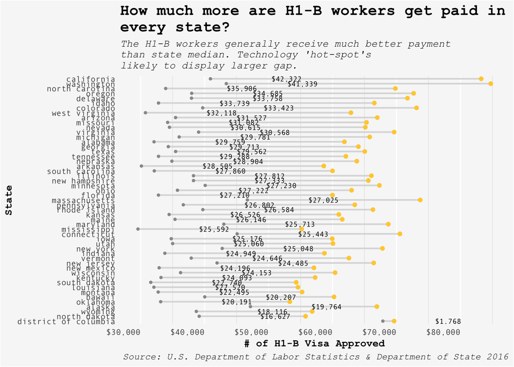

In this chart, we can clearly see that H1-B workers are paid much higher salary compared to the general median wage in every state. Technology ‘hot-spot’ states such as California and Washington displayed widest gap between the two subset of median wage. This is unsurprising because H1-B caters disproportionately to technology graduates that are more likely to be paid higher than other occupations.

##### Sevent Chart: Facet Wrap Chart

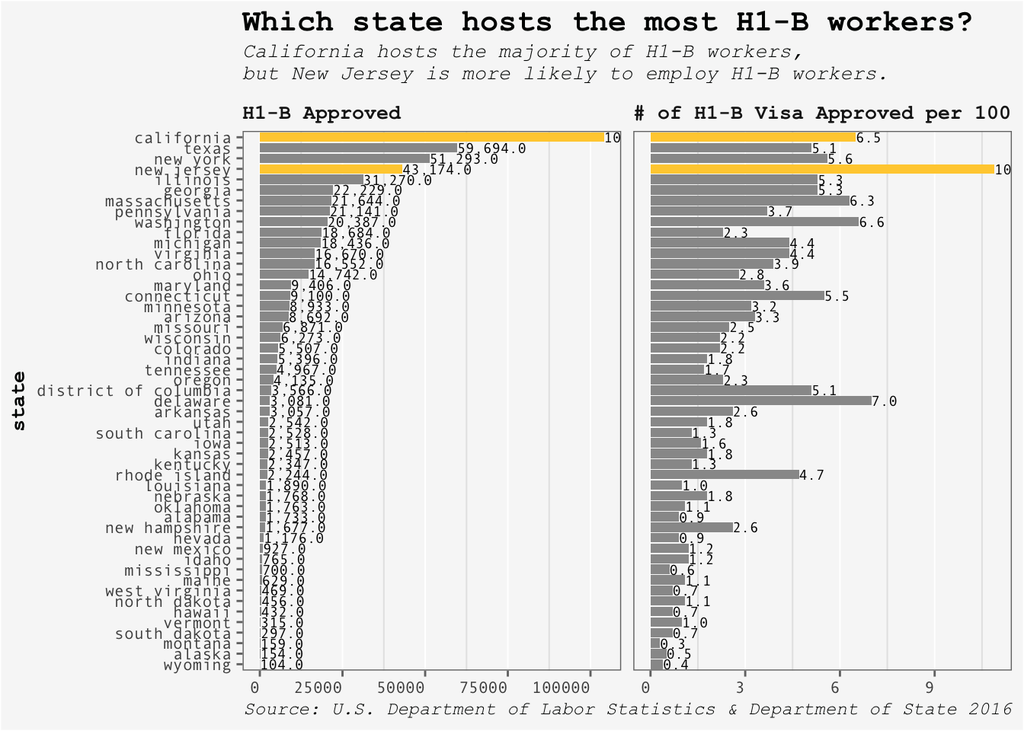

This chart showed the distribution of population and density (per 1000 workers) of H1-B approved workers in 2016. California, where Sillicon Valley is based, unsurprisingly tops the chart in terms of H1-B intake. New Jersey, in the other hand, surprisingly appears to have the highest concentration of H1-B workers in their workforce.

##### CLOROPLETH MAP 2

```
## [1] "SpatialPolygonsDataFrame"
## attr(,"package")
## [1] "sp"
```

```
## [1] "+proj=longlat +datum=WGS84 +no_defs +ellps=WGS84 +towgs84=0,0,0"
```

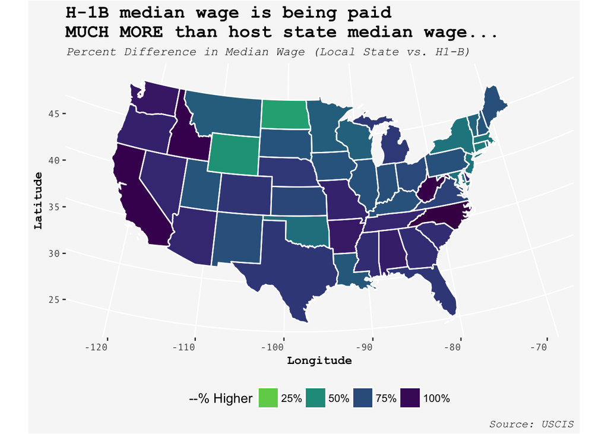

##### CLOROPLETH MAP 2

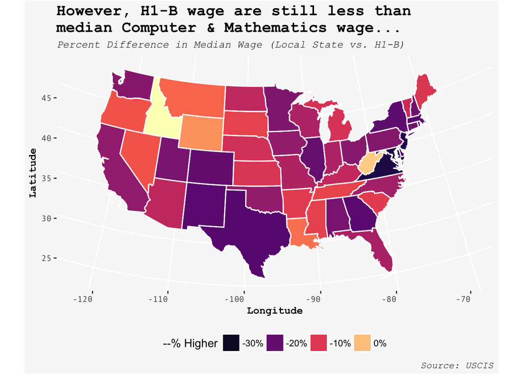